# 3.3 Model

```python
import pandas as pd
import numpy as np

import matplotlib.pyplot as plt
import seaborn as sns
```

```python
df = pd.read_csv('new_100000_rows_for_hua.txt')
list_saxenda_plantrak = pd.read_csv('plantrak_id where total paid claims Saxenda more than 0.txt')
```

```python
select_cols = [
  'patient_id',
  'patient_birth_year',
  'patient_gender',
  'age_during_first_diagnosis',
  'age_during_latest_diagnosis',
  'bmi_latest',
  'any_wt_cm_dx_yn',
  'avg_opc_generic_aoms',
  'avg_opc_other_branded_aoms',
  'avg_opc_saxenda',
  'baom_label_adolescent_yn',
  'baom_label_adult_yn',
  'days_between_first_diag_first_prescr',
  'days_between_first_diag_latest_diag',
  'days_between_first_diag_latest_prescr',
  'days_between_first_prescr_latest_prescr',
  'days_between_latest_diag_first_prescr',
  'days_between_latest_diag_latest_prescr',
  'dx_most_freq_plantrak_id',
  # 'dx_most_freq_prescriber_id',
  'dx_most_freq_state',
  'dx_most_freq_zip',
  'obesity_dx_yn',
  'obesity_or_ow_and_cm_yn',
  'prescribed_generic_aoms_yn',
  'prescribed_other_branded_aoms_yn',
  'prescribed_saxenda_yn',
  'rx_first_plantrak_id',
  'rx_first_prescriber_id',
  'rx_first_prescriber_state',
  'rx_first_prescriber_zip',
  'rx_latest_plantrak_id',
  'rx_latest_prescriber_id',
  'rx_latest_prescriber_state',
  'rx_latest_prescriber_zip',
  'rx_most_freq_plantrak_id',
  'rx_most_freq_prescriber_id',
  'rx_most_freq_state',
  'rx_most_freq_zip',
  'total_pd_claims',
  'total_pd_saxenda_claims',
  'total_pd_contrave_claims',
  'total_pd_qsymia_claims',
  'total_pd_belviq_claims',
  'total_pd_generic_claims',
  'joined_prescriber_id',
  'nni_saxenda_gsb',
  'nni_saxenda_target',
  'zip',
  'state',
  'joined_plantrak_id',
  'first_paid_prescription_date',
  'latest_paid_prescription_date'
  ]
```

Most_freq_plantrak_ID is actually a categorical column

```python
df_sel = df[select_cols]
df_sel
```

|  | patient_id | patient_birth_year | patient_gender | age_during_first_diagnosis | age_during_latest_diagnosis | bmi_latest | any_wt_cm_dx_yn | avg_opc_generic_aoms | avg_opc_other_branded_aoms | avg_opc_saxenda | ... | total_pd_belviq_claims | total_pd_generic_claims | joined_prescriber_id | nni_saxenda_gsb | nni_saxenda_target | zip | state | joined_plantrak_id | first_paid_prescription_date | latest_paid_prescription_date |
| --- | --- | --- | --- | --- | --- | --- | --- | --- | --- | --- | --- | --- | --- | --- | --- | --- | --- | --- | --- | --- | --- |
| 0 | 648980455 | 1952 | F | 63.0 | 67.0 | 27 | Y | NaN | NaN | NaN | ... | NaN | NaN | 4806922 | NaN | N | 90405 | CA | 669999 | NaN | NaN |
| 1 | 1142305110 | 2009 | M | 9.0 | 10.0 | NaN | N | NaN | NaN | NaN | ... | NaN | NaN | 1473344 | NaN | NaN | 78504 | TX | 200054 | NaN | NaN |
| 2 | 3421585012 | 1978 | F | 38.0 | 40.0 | >30 | N | NaN | NaN | NaN | ... | NaN | NaN | 2359945 | NaN | NaN | 21224 | MD | 36290018 | NaN | NaN |
| 3 | 2166437513 | 1973 | M | 42.0 | 43.0 | >30 | Y | NaN | NaN | NaN | ... | NaN | NaN | 3716761 | NaN | N | 32405 | FL | 12900159 | NaN | NaN |
| 4 | 928754501 | 2008 | M | 7.0 | 10.0 | NaN | N | NaN | NaN | NaN | ... | NaN | NaN | 1270478 | NaN | NaN | 44504 | OH | 200542 | NaN | NaN |
| ... | ... | ... | ... | ... | ... | ... | ... | ... | ... | ... | ... | ... | ... | ... | ... | ... | ... | ... | ... | ... | ... |
| 99995 | 1187762182 | 2008 | F | 9.0 | 10.0 | NaN | N | NaN | NaN | NaN | ... | NaN | NaN | 5434107 | NaN | NaN | 44053 | OH | 6140485 | NaN | NaN |
| 99996 | 1232193713 | 1959 | M | 56.0 | 59.0 | 27 | Y | NaN | NaN | NaN | ... | NaN | NaN | 2513590 | NaN | NaN | 90057 | CA | 669999 | NaN | NaN |
| 99997 | 1400144960 | 1983 | F | NaN | NaN | NaN | NaN | 25.15 | NaN | NaN | ... | 0.0 | 20.0 | 1840943 | Tier 2 | Y | 75246 | TX | 36760004 | 2015-04-20 | 2019-12-11 |
| 99998 | 1001166815 | 1996 | F | NaN | NaN | NaN | NaN | 19.11 | NaN | NaN | ... | 0.0 | 2.0 | 2141207 | Tier 2 | Y | 71301 | LA | 7020014 | 2017-10-02 | 2017-10-26 |
| 99999 | 583994839 | 1968 | F | 47.0 | 51.0 | >30 | N | NaN | NaN | NaN | ... | NaN | NaN | 769253 | NaN | NaN | 2646 | MA | 209999 | NaN | NaN |

100000 rows × 52 columns

```python
col_yn = [col for col in df_sel.columns if 'yn' in col]
col_yn = col_yn+['nni_saxenda_target']
col_yn
```

```
['any_wt_cm_dx_yn',
 'baom_label_adolescent_yn',
 'baom_label_adult_yn',
 'obesity_dx_yn',
 'obesity_or_ow_and_cm_yn',
 'prescribed_generic_aoms_yn',
 'prescribed_other_branded_aoms_yn',
 'prescribed_saxenda_yn',
 'nni_saxenda_target']
```

```python
df_sel[col_yn]=df_sel[col_yn].replace({'Y':1,'N':0})
```

```python
df_sel_aom = df_sel[~(df_sel.avg_opc_other_branded_aoms.isna())^(df_sel.avg_opc_generic_aoms.isna())^(df_sel.avg_opc_saxenda.isna())]
```

# 2. Cleaning

```python
df_sel
```

|  | patient_id | patient_birth_year | patient_gender | age_during_first_diagnosis | age_during_latest_diagnosis | bmi_latest | any_wt_cm_dx_yn | avg_opc_generic_aoms | avg_opc_other_branded_aoms | avg_opc_saxenda | ... | total_pd_belviq_claims | total_pd_generic_claims | joined_prescriber_id | nni_saxenda_gsb | nni_saxenda_target | zip | state | joined_plantrak_id | first_paid_prescription_date | latest_paid_prescription_date |
| --- | --- | --- | --- | --- | --- | --- | --- | --- | --- | --- | --- | --- | --- | --- | --- | --- | --- | --- | --- | --- | --- |
| 0 | 648980455 | 1952 | F | 63.0 | 67.0 | 27 | 1.0 | NaN | NaN | NaN | ... | NaN | NaN | 4806922 | NaN | 0.0 | 90405 | CA | 669999 | NaN | NaN |
| 1 | 1142305110 | 2009 | M | 9.0 | 10.0 | NaN | 0.0 | NaN | NaN | NaN | ... | NaN | NaN | 1473344 | NaN | NaN | 78504 | TX | 200054 | NaN | NaN |
| 2 | 3421585012 | 1978 | F | 38.0 | 40.0 | >30 | 0.0 | NaN | NaN | NaN | ... | NaN | NaN | 2359945 | NaN | NaN | 21224 | MD | 36290018 | NaN | NaN |
| 3 | 2166437513 | 1973 | M | 42.0 | 43.0 | >30 | 1.0 | NaN | NaN | NaN | ... | NaN | NaN | 3716761 | NaN | 0.0 | 32405 | FL | 12900159 | NaN | NaN |
| 4 | 928754501 | 2008 | M | 7.0 | 10.0 | NaN | 0.0 | NaN | NaN | NaN | ... | NaN | NaN | 1270478 | NaN | NaN | 44504 | OH | 200542 | NaN | NaN |
| ... | ... | ... | ... | ... | ... | ... | ... | ... | ... | ... | ... | ... | ... | ... | ... | ... | ... | ... | ... | ... | ... |
| 99995 | 1187762182 | 2008 | F | 9.0 | 10.0 | NaN | 0.0 | NaN | NaN | NaN | ... | NaN | NaN | 5434107 | NaN | NaN | 44053 | OH | 6140485 | NaN | NaN |
| 99996 | 1232193713 | 1959 | M | 56.0 | 59.0 | 27 | 1.0 | NaN | NaN | NaN | ... | NaN | NaN | 2513590 | NaN | NaN | 90057 | CA | 669999 | NaN | NaN |
| 99997 | 1400144960 | 1983 | F | NaN | NaN | NaN | NaN | 25.15 | NaN | NaN | ... | 0.0 | 20.0 | 1840943 | Tier 2 | 1.0 | 75246 | TX | 36760004 | 2015-04-20 | 2019-12-11 |
| 99998 | 1001166815 | 1996 | F | NaN | NaN | NaN | NaN | 19.11 | NaN | NaN | ... | 0.0 | 2.0 | 2141207 | Tier 2 | 1.0 | 71301 | LA | 7020014 | 2017-10-02 | 2017-10-26 |
| 99999 | 583994839 | 1968 | F | 47.0 | 51.0 | >30 | 0.0 | NaN | NaN | NaN | ... | NaN | NaN | 769253 | NaN | NaN | 2646 | MA | 209999 | NaN | NaN |

100000 rows × 52 columns

## 2.1 If the plantrak_id correspond to saxenda paid claim before, this plantrak is considered to cover Saxenda

```python
list_saxenda_plantrak = list_saxenda_plantrak.assign(Saxenda_Plantrak=True)
list_saxenda_plantrak
```

|  | joined_plantrak_id | Saxenda_Plantrak |
| --- | --- | --- |
| 0 | 8888880012 | True |
| 1 | 8888880009 | True |
| 2 | 8888880006 | True |
| 3 | 8888880005 | True |
| 4 | 8888880002 | True |
| ... | ... | ... |
| 4845 | 20007 | True |
| 4846 | 20006 | True |
| 4847 | 20005 | True |
| 4848 | 20002 | True |
| 4849 | 10001 | True |

4850 rows × 2 columns

```python
df_sel_1 = df_sel.merge(list_saxenda_plantrak, how = 'left', on='joined_plantrak_id',)
df_sel_1.Saxenda_Plantrak = df_sel_1.Saxenda_Plantrak.fillna(False)
df_sel_1.Saxenda_Plantrak = df_sel_1.Saxenda_Plantrak.astype('int')
df_sel_1
```

|  | patient_id | patient_birth_year | patient_gender | age_during_first_diagnosis | age_during_latest_diagnosis | bmi_latest | any_wt_cm_dx_yn | avg_opc_generic_aoms | avg_opc_other_branded_aoms | avg_opc_saxenda | ... | total_pd_generic_claims | joined_prescriber_id | nni_saxenda_gsb | nni_saxenda_target | zip | state | joined_plantrak_id | first_paid_prescription_date | latest_paid_prescription_date | Saxenda_Plantrak |
| --- | --- | --- | --- | --- | --- | --- | --- | --- | --- | --- | --- | --- | --- | --- | --- | --- | --- | --- | --- | --- | --- |
| 0 | 648980455 | 1952 | F | 63.0 | 67.0 | 27 | 1.0 | NaN | NaN | NaN | ... | NaN | 4806922 | NaN | 0.0 | 90405 | CA | 669999 | NaN | NaN | 1 |
| 1 | 1142305110 | 2009 | M | 9.0 | 10.0 | NaN | 0.0 | NaN | NaN | NaN | ... | NaN | 1473344 | NaN | NaN | 78504 | TX | 200054 | NaN | NaN | 1 |
| 2 | 3421585012 | 1978 | F | 38.0 | 40.0 | >30 | 0.0 | NaN | NaN | NaN | ... | NaN | 2359945 | NaN | NaN | 21224 | MD | 36290018 | NaN | NaN | 0 |
| 3 | 2166437513 | 1973 | M | 42.0 | 43.0 | >30 | 1.0 | NaN | NaN | NaN | ... | NaN | 3716761 | NaN | 0.0 | 32405 | FL | 12900159 | NaN | NaN | 0 |
| 4 | 928754501 | 2008 | M | 7.0 | 10.0 | NaN | 0.0 | NaN | NaN | NaN | ... | NaN | 1270478 | NaN | NaN | 44504 | OH | 200542 | NaN | NaN | 1 |
| ... | ... | ... | ... | ... | ... | ... | ... | ... | ... | ... | ... | ... | ... | ... | ... | ... | ... | ... | ... | ... | ... |
| 99995 | 1187762182 | 2008 | F | 9.0 | 10.0 | NaN | 0.0 | NaN | NaN | NaN | ... | NaN | 5434107 | NaN | NaN | 44053 | OH | 6140485 | NaN | NaN | 1 |
| 99996 | 1232193713 | 1959 | M | 56.0 | 59.0 | 27 | 1.0 | NaN | NaN | NaN | ... | NaN | 2513590 | NaN | NaN | 90057 | CA | 669999 | NaN | NaN | 1 |
| 99997 | 1400144960 | 1983 | F | NaN | NaN | NaN | NaN | 25.15 | NaN | NaN | ... | 20.0 | 1840943 | Tier 2 | 1.0 | 75246 | TX | 36760004 | 2015-04-20 | 2019-12-11 | 1 |
| 99998 | 1001166815 | 1996 | F | NaN | NaN | NaN | NaN | 19.11 | NaN | NaN | ... | 2.0 | 2141207 | Tier 2 | 1.0 | 71301 | LA | 7020014 | 2017-10-02 | 2017-10-26 | 1 |
| 99999 | 583994839 | 1968 | F | 47.0 | 51.0 | >30 | 0.0 | NaN | NaN | NaN | ... | NaN | 769253 | NaN | NaN | 2646 | MA | 209999 | NaN | NaN | 1 |

100000 rows × 53 columns

```python
df_sel_DR = df_sel_1[~(df_sel_1.bmi_latest.isna())]
df_sel_R = df_sel_1[(df_sel_1.bmi_latest.isna())]
```

# 3. Select Patients that has DX&RX data. Does not care about opc. Dropna.

## 3.1 df_sel_DR_dropopc_claimY: Diagnosed and Prescribed and has paid claims infomation

```python
# df_sel_DR_complete = df_sel_DR[~(df_sel_DR.total_pd_claims.isna())].drop(columns=['avg_opc_generic_aoms',	'avg_opc_other_branded_aoms',	'avg_opc_saxenda']).dropna()
df_sel_DR_dropopc = df_sel_DR.drop(columns=['avg_opc_generic_aoms',	'avg_opc_other_branded_aoms',	'avg_opc_saxenda'])
df_sel_DR_dropopc_claimY = df_sel_DR_dropopc[~(df_sel_DR_dropopc.total_pd_claims.isna())]
df_sel_DR_dropopc_claimY
```

|  | patient_id | patient_birth_year | patient_gender | age_during_first_diagnosis | age_during_latest_diagnosis | bmi_latest | any_wt_cm_dx_yn | baom_label_adolescent_yn | baom_label_adult_yn | days_between_first_diag_first_prescr | ... | total_pd_generic_claims | joined_prescriber_id | nni_saxenda_gsb | nni_saxenda_target | zip | state | joined_plantrak_id | first_paid_prescription_date | latest_paid_prescription_date | Saxenda_Plantrak |
| --- | --- | --- | --- | --- | --- | --- | --- | --- | --- | --- | --- | --- | --- | --- | --- | --- | --- | --- | --- | --- | --- |
| 14 | 1458911665 | 1980 | F | 35.0 | 39.0 | >30 | 1.0 | 0.0 | 1.0 | 267.0 | ... | 1.0 | 6122518 | Tier 3 | 0.0 | 72529 | AR | 30144 | 2016-02-10 | 2019-07-29 | 1 |
| 20 | 606519113 | 1962 | F | 53.0 | 56.0 | >30 | 1.0 | 0.0 | 1.0 | 1064.0 | ... | 1.0 | 4178232 | No Tier | 0.0 | 30097 | GA | 35710003 | 2018-03-19 | 2018-03-19 | 1 |
| 23 | 676106601 | 1971 | F | 46.0 | 46.0 | >30 | 0.0 | 0.0 | 1.0 | -949.0 | ... | 4.0 | 4271742 | Tier 2 | 1.0 | 75230 | TX | 7000270678 | 2015-04-02 | 2016-10-27 | 1 |
| 26 | 824770362 | 1968 | F | 47.0 | 48.0 | >30 | 1.0 | 0.0 | 1.0 | 341.0 | ... | 3.0 | 1325501 | Tier 3 | 1.0 | 45040 | OH | 129999 | 2016-03-14 | 2016-09-07 | 1 |
| 39 | 162223442 | 1963 | F | 52.0 | 56.0 | 27 | 1.0 | 0.0 | 1.0 | -7.0 | ... | 4.0 | 129891 | NaN | NaN | 29556 | SC | 31730004 | 2015-04-09 | 2015-08-28 | 1 |
| ... | ... | ... | ... | ... | ... | ... | ... | ... | ... | ... | ... | ... | ... | ... | ... | ... | ... | ... | ... | ... | ... |
| 99937 | 562599472 | 1966 | F | 49.0 | 53.0 | >30 | 1.0 | 0.0 | 1.0 | NaN | ... | 1.0 | 1753149 | Tier 3 | 0.0 | 70816 | LA | 26220001 | 2016-08-18 | 2016-08-18 | 1 |
| 99938 | 1150109365 | 1968 | F | 48.0 | 51.0 | >30 | 0.0 | 0.0 | 1.0 | -223.0 | ... | 0.0 | 393485 | NaN | NaN | 90211 | CA | 6140008 | 2015-12-31 | 2018-05-09 | 1 |
| 99959 | 2744837984 | 1975 | F | 40.0 | 44.0 | >30 | 0.0 | 0.0 | 1.0 | 1246.0 | ... | 7.0 | 1583772 | Tier 1 | 1.0 | 74133 | OK | 12610034 | 2019-02-07 | 2019-10-28 | 1 |
| 99974 | 710528213 | 1994 | F | 21.0 | 24.0 | >30 | 0.0 | 0.0 | 1.0 | 836.0 | ... | 5.0 | 3497275 | Tier 3 | 0.0 | 88220 | NM | 4530005 | 2017-08-21 | 2018-08-02 | 1 |
| 99985 | 2879339771 | 1956 | F | 59.0 | 63.0 | 27 | 1.0 | 0.0 | 1.0 | 115.0 | ... | 1.0 | 5019917 | Tier 3 | 1.0 | 29615 | SC | 7002360001 | 2016-03-07 | 2016-03-07 | 1 |

6002 rows × 50 columns

## 3.2 Keep droping some columns

```python
kept_cols = ['patient_id',
 'patient_birth_year',
 'patient_gender',
 'age_during_first_diagnosis',
#  'age_during_latest_diagnosis',
 'bmi_latest',
 'any_wt_cm_dx_yn',
 'baom_label_adolescent_yn',
 'baom_label_adult_yn',
#  'days_between_first_diag_first_prescr',
#  'days_between_first_diag_latest_diag',
#  'days_between_first_diag_latest_prescr',
 'days_between_first_prescr_latest_prescr',
#  'days_between_latest_diag_first_prescr',
#  'days_between_latest_diag_latest_prescr',
#  'dx_most_freq_plantrak_id',
#  'dx_most_freq_state',
#  'dx_most_freq_zip',
 'obesity_dx_yn',
 'obesity_or_ow_and_cm_yn',
 'prescribed_generic_aoms_yn',
 'prescribed_other_branded_aoms_yn',
 'prescribed_saxenda_yn',
#  'rx_first_plantrak_id',
#  'rx_first_prescriber_id',
#  'rx_first_prescriber_state',
#  'rx_first_prescriber_zip',
#  'rx_latest_plantrak_id',
#  'rx_latest_prescriber_id',
#  'rx_latest_prescriber_state',
#  'rx_latest_prescriber_zip',
#  'rx_most_freq_plantrak_id',
#  'rx_most_freq_prescriber_id',
#  'rx_most_freq_state',
#  'rx_most_freq_zip',
 'total_pd_claims',
 'total_pd_saxenda_claims',
 'total_pd_contrave_claims',
 'total_pd_qsymia_claims',
 'total_pd_belviq_claims',
 'total_pd_generic_claims',
 'joined_prescriber_id',
 'nni_saxenda_gsb',
 'nni_saxenda_target',
 'zip',
 'state',
 'joined_plantrak_id',
 'first_paid_prescription_date',
 'latest_paid_prescription_date',
 'Saxenda_Plantrak']
```

```python
df_sel_DR_dropopc_claimY = df_sel_DR_dropopc_claimY[kept_cols]
df_sel_DR_dropopc_claimY
```

|  | patient_id | patient_birth_year | patient_gender | age_during_first_diagnosis | bmi_latest | any_wt_cm_dx_yn | baom_label_adolescent_yn | baom_label_adult_yn | days_between_first_prescr_latest_prescr | obesity_dx_yn | ... | total_pd_generic_claims | joined_prescriber_id | nni_saxenda_gsb | nni_saxenda_target | zip | state | joined_plantrak_id | first_paid_prescription_date | latest_paid_prescription_date | Saxenda_Plantrak |
| --- | --- | --- | --- | --- | --- | --- | --- | --- | --- | --- | --- | --- | --- | --- | --- | --- | --- | --- | --- | --- | --- |
| 14 | 1458911665 | 1980 | F | 35.0 | >30 | 1.0 | 0.0 | 1.0 | 1271.0 | 1.0 | ... | 1.0 | 6122518 | Tier 3 | 0.0 | 72529 | AR | 30144 | 2016-02-10 | 2019-07-29 | 1 |
| 20 | 606519113 | 1962 | F | 53.0 | >30 | 1.0 | 0.0 | 1.0 | 0.0 | 1.0 | ... | 1.0 | 4178232 | No Tier | 0.0 | 30097 | GA | 35710003 | 2018-03-19 | 2018-03-19 | 1 |
| 23 | 676106601 | 1971 | F | 46.0 | >30 | 0.0 | 0.0 | 1.0 | 574.0 | 1.0 | ... | 4.0 | 4271742 | Tier 2 | 1.0 | 75230 | TX | 7000270678 | 2015-04-02 | 2016-10-27 | 1 |
| 26 | 824770362 | 1968 | F | 47.0 | >30 | 1.0 | 0.0 | 1.0 | 177.0 | 1.0 | ... | 3.0 | 1325501 | Tier 3 | 1.0 | 45040 | OH | 129999 | 2016-03-14 | 2016-09-07 | 1 |
| 39 | 162223442 | 1963 | F | 52.0 | 27 | 1.0 | 0.0 | 1.0 | 141.0 | 0.0 | ... | 4.0 | 129891 | NaN | NaN | 29556 | SC | 31730004 | 2015-04-09 | 2015-08-28 | 1 |
| ... | ... | ... | ... | ... | ... | ... | ... | ... | ... | ... | ... | ... | ... | ... | ... | ... | ... | ... | ... | ... | ... |
| 99937 | 562599472 | 1966 | F | 49.0 | >30 | 1.0 | 0.0 | 1.0 | 74.0 | 1.0 | ... | 1.0 | 1753149 | Tier 3 | 0.0 | 70816 | LA | 26220001 | 2016-08-18 | 2016-08-18 | 1 |
| 99938 | 1150109365 | 1968 | F | 48.0 | >30 | 0.0 | 0.0 | 1.0 | 876.0 | 1.0 | ... | 0.0 | 393485 | NaN | NaN | 90211 | CA | 6140008 | 2015-12-31 | 2018-05-09 | 1 |
| 99959 | 2744837984 | 1975 | F | 40.0 | >30 | 0.0 | 0.0 | 1.0 | 228.0 | 1.0 | ... | 7.0 | 1583772 | Tier 1 | 1.0 | 74133 | OK | 12610034 | 2019-02-07 | 2019-10-28 | 1 |
| 99974 | 710528213 | 1994 | F | 21.0 | >30 | 0.0 | 0.0 | 1.0 | 350.0 | 1.0 | ... | 5.0 | 3497275 | Tier 3 | 0.0 | 88220 | NM | 4530005 | 2017-08-21 | 2018-08-02 | 1 |
| 99985 | 2879339771 | 1956 | F | 59.0 | 27 | 1.0 | 0.0 | 1.0 | 0.0 | 0.0 | ... | 1.0 | 5019917 | Tier 3 | 1.0 | 29615 | SC | 7002360001 | 2016-03-07 | 2016-03-07 | 1 |

6002 rows × 29 columns

## 3.3 Only keep `days_between_first_pdprescr_latest_pdprescr`

```python
df_sel_DR_dropopc_claimY = df_sel_DR_dropopc_claimY.assign(days_between_first_pdprescr_latest_pdprescr = lambda x: ((pd.to_datetime(x.latest_paid_prescription_date).dt.date-pd.to_datetime(x.first_paid_prescription_date).dt.date)).dt.days)
df_sel_DR_dropopc_claimY = df_sel_DR_dropopc_claimY.drop(
    [
     'first_paid_prescription_date',
     'latest_paid_prescription_date',
     'days_between_first_prescr_latest_prescr'
    ],
    axis=1
)
```

```python
df_sel_DR_dropopc_claimY
```

|  | patient_id | patient_birth_year | patient_gender | age_during_first_diagnosis | bmi_latest | any_wt_cm_dx_yn | baom_label_adolescent_yn | baom_label_adult_yn | obesity_dx_yn | obesity_or_ow_and_cm_yn | ... | total_pd_belviq_claims | total_pd_generic_claims | joined_prescriber_id | nni_saxenda_gsb | nni_saxenda_target | zip | state | joined_plantrak_id | Saxenda_Plantrak | days_between_first_pdprescr_latest_pdprescr |
| --- | --- | --- | --- | --- | --- | --- | --- | --- | --- | --- | --- | --- | --- | --- | --- | --- | --- | --- | --- | --- | --- |
| 14 | 1458911665 | 1980 | F | 35.0 | >30 | 1.0 | 0.0 | 1.0 | 1.0 | 1.0 | ... | 0.0 | 1.0 | 6122518 | Tier 3 | 0.0 | 72529 | AR | 30144 | 1 | 1265.0 |
| 20 | 606519113 | 1962 | F | 53.0 | >30 | 1.0 | 0.0 | 1.0 | 1.0 | 1.0 | ... | 0.0 | 1.0 | 4178232 | No Tier | 0.0 | 30097 | GA | 35710003 | 1 | 0.0 |
| 23 | 676106601 | 1971 | F | 46.0 | >30 | 0.0 | 0.0 | 1.0 | 1.0 | 1.0 | ... | 0.0 | 4.0 | 4271742 | Tier 2 | 1.0 | 75230 | TX | 7000270678 | 1 | 574.0 |
| 26 | 824770362 | 1968 | F | 47.0 | >30 | 1.0 | 0.0 | 1.0 | 1.0 | 1.0 | ... | 0.0 | 3.0 | 1325501 | Tier 3 | 1.0 | 45040 | OH | 129999 | 1 | 177.0 |
| 39 | 162223442 | 1963 | F | 52.0 | 27 | 1.0 | 0.0 | 1.0 | 0.0 | 1.0 | ... | 0.0 | 4.0 | 129891 | NaN | NaN | 29556 | SC | 31730004 | 1 | 141.0 |
| ... | ... | ... | ... | ... | ... | ... | ... | ... | ... | ... | ... | ... | ... | ... | ... | ... | ... | ... | ... | ... | ... |
| 99937 | 562599472 | 1966 | F | 49.0 | >30 | 1.0 | 0.0 | 1.0 | 1.0 | 1.0 | ... | 0.0 | 1.0 | 1753149 | Tier 3 | 0.0 | 70816 | LA | 26220001 | 1 | 0.0 |
| 99938 | 1150109365 | 1968 | F | 48.0 | >30 | 0.0 | 0.0 | 1.0 | 1.0 | 1.0 | ... | 2.0 | 0.0 | 393485 | NaN | NaN | 90211 | CA | 6140008 | 1 | 860.0 |
| 99959 | 2744837984 | 1975 | F | 40.0 | >30 | 0.0 | 0.0 | 1.0 | 1.0 | 1.0 | ... | 0.0 | 7.0 | 1583772 | Tier 1 | 1.0 | 74133 | OK | 12610034 | 1 | 263.0 |
| 99974 | 710528213 | 1994 | F | 21.0 | >30 | 0.0 | 0.0 | 1.0 | 1.0 | 1.0 | ... | 0.0 | 5.0 | 3497275 | Tier 3 | 0.0 | 88220 | NM | 4530005 | 1 | 346.0 |
| 99985 | 2879339771 | 1956 | F | 59.0 | 27 | 1.0 | 0.0 | 1.0 | 0.0 | 1.0 | ... | 0.0 | 1.0 | 5019917 | Tier 3 | 1.0 | 29615 | SC | 7002360001 | 1 | 0.0 |

6002 rows × 27 columns

## 3.4 Encode other variables

### 3.4.1 patient gender

```python
df_sel_DR_dropopc_claimY.patient_gender = df_sel_DR_dropopc_claimY.patient_gender.replace({'M':1,'F':0})
df_sel_DR_dropopc_claimY = df_sel_DR_dropopc_claimY.rename(columns={'patient_gender':'patient_male_yn'})
df_sel_DR_dropopc_claimY
```

|  | patient_id | patient_birth_year | patient_male_yn | age_during_first_diagnosis | bmi_latest | any_wt_cm_dx_yn | baom_label_adolescent_yn | baom_label_adult_yn | obesity_dx_yn | obesity_or_ow_and_cm_yn | ... | total_pd_belviq_claims | total_pd_generic_claims | joined_prescriber_id | nni_saxenda_gsb | nni_saxenda_target | zip | state | joined_plantrak_id | Saxenda_Plantrak | days_between_first_pdprescr_latest_pdprescr |
| --- | --- | --- | --- | --- | --- | --- | --- | --- | --- | --- | --- | --- | --- | --- | --- | --- | --- | --- | --- | --- | --- |
| 14 | 1458911665 | 1980 | 0 | 35.0 | >30 | 1.0 | 0.0 | 1.0 | 1.0 | 1.0 | ... | 0.0 | 1.0 | 6122518 | Tier 3 | 0.0 | 72529 | AR | 30144 | 1 | 1265.0 |
| 20 | 606519113 | 1962 | 0 | 53.0 | >30 | 1.0 | 0.0 | 1.0 | 1.0 | 1.0 | ... | 0.0 | 1.0 | 4178232 | No Tier | 0.0 | 30097 | GA | 35710003 | 1 | 0.0 |
| 23 | 676106601 | 1971 | 0 | 46.0 | >30 | 0.0 | 0.0 | 1.0 | 1.0 | 1.0 | ... | 0.0 | 4.0 | 4271742 | Tier 2 | 1.0 | 75230 | TX | 7000270678 | 1 | 574.0 |
| 26 | 824770362 | 1968 | 0 | 47.0 | >30 | 1.0 | 0.0 | 1.0 | 1.0 | 1.0 | ... | 0.0 | 3.0 | 1325501 | Tier 3 | 1.0 | 45040 | OH | 129999 | 1 | 177.0 |
| 39 | 162223442 | 1963 | 0 | 52.0 | 27 | 1.0 | 0.0 | 1.0 | 0.0 | 1.0 | ... | 0.0 | 4.0 | 129891 | NaN | NaN | 29556 | SC | 31730004 | 1 | 141.0 |
| ... | ... | ... | ... | ... | ... | ... | ... | ... | ... | ... | ... | ... | ... | ... | ... | ... | ... | ... | ... | ... | ... |
| 99937 | 562599472 | 1966 | 0 | 49.0 | >30 | 1.0 | 0.0 | 1.0 | 1.0 | 1.0 | ... | 0.0 | 1.0 | 1753149 | Tier 3 | 0.0 | 70816 | LA | 26220001 | 1 | 0.0 |
| 99938 | 1150109365 | 1968 | 0 | 48.0 | >30 | 0.0 | 0.0 | 1.0 | 1.0 | 1.0 | ... | 2.0 | 0.0 | 393485 | NaN | NaN | 90211 | CA | 6140008 | 1 | 860.0 |
| 99959 | 2744837984 | 1975 | 0 | 40.0 | >30 | 0.0 | 0.0 | 1.0 | 1.0 | 1.0 | ... | 0.0 | 7.0 | 1583772 | Tier 1 | 1.0 | 74133 | OK | 12610034 | 1 | 263.0 |
| 99974 | 710528213 | 1994 | 0 | 21.0 | >30 | 0.0 | 0.0 | 1.0 | 1.0 | 1.0 | ... | 0.0 | 5.0 | 3497275 | Tier 3 | 0.0 | 88220 | NM | 4530005 | 1 | 346.0 |
| 99985 | 2879339771 | 1956 | 0 | 59.0 | 27 | 1.0 | 0.0 | 1.0 | 0.0 | 1.0 | ... | 0.0 | 1.0 | 5019917 | Tier 3 | 1.0 | 29615 | SC | 7002360001 | 1 | 0.0 |

6002 rows × 27 columns

```python
df_sel_DR_dropopc_claimY.patient_male_yn.unique()
```

```
array([0, 1, 'U'], dtype=object)
```

```python
df_sel_DR_dropopc_claimY = df_sel_DR_dropopc_claimY[df_sel_DR_dropopc_claimY.patient_male_yn!='U']
df_sel_DR_dropopc_claimY.patient_male_yn = df_sel_DR_dropopc_claimY.patient_male_yn.astype('int')
```

```python
df_sel_DR_dropopc_claimY.columns
```

```
Index(['patient_id', 'patient_birth_year', 'patient_male_yn',
       'age_during_first_diagnosis', 'bmi_latest', 'any_wt_cm_dx_yn',
       'baom_label_adolescent_yn', 'baom_label_adult_yn', 'obesity_dx_yn',
       'obesity_or_ow_and_cm_yn', 'prescribed_generic_aoms_yn',
       'prescribed_other_branded_aoms_yn', 'prescribed_saxenda_yn',
       'total_pd_claims', 'total_pd_saxenda_claims',
       'total_pd_contrave_claims', 'total_pd_qsymia_claims',
       'total_pd_belviq_claims', 'total_pd_generic_claims',
       'joined_prescriber_id', 'nni_saxenda_gsb', 'nni_saxenda_target', 'zip',
       'state', 'joined_plantrak_id', 'Saxenda_Plantrak',
       'days_between_first_pdprescr_latest_pdprescr'],
      dtype='object')
```

### 3.4.2 Make bins for `days_betweeen`

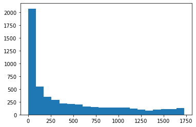

```python
plt.hist(df_sel_DR_dropopc_claimY.days_between_first_pdprescr_latest_pdprescr,bins=20)
```

```python
df_sel_DR_dropopc_claimY.days_between_first_pdprescr_latest_pdprescr.quantile(np.linspace(0,1,21))
```

```
0.00       0.0
0.05       0.0
0.10       0.0
0.15       0.0
0.20       0.0
0.25      27.0
0.30      44.0
0.35      70.0
0.40     102.4
0.45     145.2
0.50     204.0
0.55     270.0
0.60     353.0
0.65     466.4
0.70     582.0
0.75     728.0
0.80     904.6
0.85    1078.6
0.90    1282.4
0.95    1534.0
1.00    1729.0
Name: days_between_first_pdprescr_latest_pdprescr, dtype: float64
```

### Encode based on the cumulative distribution?

```python
bins = [-1,1,50,100,200,350,600,900,1300,np.inf]
pd.cut(df_sel_DR_dropopc_claimY.days_between_first_pdprescr_latest_pdprescr, bins)
```

```
14       (900.0, 1300.0]
20           (-1.0, 1.0]
23        (350.0, 600.0]
26        (100.0, 200.0]
39        (100.0, 200.0]
              ...
99937        (-1.0, 1.0]
99938     (600.0, 900.0]
99959     (200.0, 350.0]
99974     (200.0, 350.0]
99985        (-1.0, 1.0]
Name: days_between_first_pdprescr_latest_pdprescr, Length: 6001, dtype: category
Categories (9, interval[float64]): [(-1.0, 1.0] < (1.0, 50.0] < (50.0, 100.0] < (100.0, 200.0] ... (350.0, 600.0] < (600.0, 900.0] < (900.0, 1300.0] < (1300.0, inf]]
```

```python
bins = [-1,1,50,100,200,350,600,900,1300,np.inf]
df_sel_DR_dropopc_claimY = df_sel_DR_dropopc_claimY.assign(bin_pdpx_duration = lambda x: pd.cut(x.days_between_first_pdprescr_latest_pdprescr, bins))
df_sel_DR_dropopc_claimY
```

|  | patient_id | patient_birth_year | patient_male_yn | age_during_first_diagnosis | bmi_latest | any_wt_cm_dx_yn | baom_label_adolescent_yn | baom_label_adult_yn | obesity_dx_yn | obesity_or_ow_and_cm_yn | ... | total_pd_generic_claims | joined_prescriber_id | nni_saxenda_gsb | nni_saxenda_target | zip | state | joined_plantrak_id | Saxenda_Plantrak | days_between_first_pdprescr_latest_pdprescr | bin_pdpx_duration |
| --- | --- | --- | --- | --- | --- | --- | --- | --- | --- | --- | --- | --- | --- | --- | --- | --- | --- | --- | --- | --- | --- |
| 14 | 1458911665 | 1980 | 0 | 35.0 | >30 | 1.0 | 0.0 | 1.0 | 1.0 | 1.0 | ... | 1.0 | 6122518 | Tier 3 | 0.0 | 72529 | AR | 30144 | 1 | 1265.0 | (900.0, 1300.0] |
| 20 | 606519113 | 1962 | 0 | 53.0 | >30 | 1.0 | 0.0 | 1.0 | 1.0 | 1.0 | ... | 1.0 | 4178232 | No Tier | 0.0 | 30097 | GA | 35710003 | 1 | 0.0 | (-1.0, 1.0] |
| 23 | 676106601 | 1971 | 0 | 46.0 | >30 | 0.0 | 0.0 | 1.0 | 1.0 | 1.0 | ... | 4.0 | 4271742 | Tier 2 | 1.0 | 75230 | TX | 7000270678 | 1 | 574.0 | (350.0, 600.0] |
| 26 | 824770362 | 1968 | 0 | 47.0 | >30 | 1.0 | 0.0 | 1.0 | 1.0 | 1.0 | ... | 3.0 | 1325501 | Tier 3 | 1.0 | 45040 | OH | 129999 | 1 | 177.0 | (100.0, 200.0] |
| 39 | 162223442 | 1963 | 0 | 52.0 | 27 | 1.0 | 0.0 | 1.0 | 0.0 | 1.0 | ... | 4.0 | 129891 | NaN | NaN | 29556 | SC | 31730004 | 1 | 141.0 | (100.0, 200.0] |
| ... | ... | ... | ... | ... | ... | ... | ... | ... | ... | ... | ... | ... | ... | ... | ... | ... | ... | ... | ... | ... | ... |
| 99937 | 562599472 | 1966 | 0 | 49.0 | >30 | 1.0 | 0.0 | 1.0 | 1.0 | 1.0 | ... | 1.0 | 1753149 | Tier 3 | 0.0 | 70816 | LA | 26220001 | 1 | 0.0 | (-1.0, 1.0] |
| 99938 | 1150109365 | 1968 | 0 | 48.0 | >30 | 0.0 | 0.0 | 1.0 | 1.0 | 1.0 | ... | 0.0 | 393485 | NaN | NaN | 90211 | CA | 6140008 | 1 | 860.0 | (600.0, 900.0] |
| 99959 | 2744837984 | 1975 | 0 | 40.0 | >30 | 0.0 | 0.0 | 1.0 | 1.0 | 1.0 | ... | 7.0 | 1583772 | Tier 1 | 1.0 | 74133 | OK | 12610034 | 1 | 263.0 | (200.0, 350.0] |
| 99974 | 710528213 | 1994 | 0 | 21.0 | >30 | 0.0 | 0.0 | 1.0 | 1.0 | 1.0 | ... | 5.0 | 3497275 | Tier 3 | 0.0 | 88220 | NM | 4530005 | 1 | 346.0 | (200.0, 350.0] |
| 99985 | 2879339771 | 1956 | 0 | 59.0 | 27 | 1.0 | 0.0 | 1.0 | 0.0 | 1.0 | ... | 1.0 | 5019917 | Tier 3 | 1.0 | 29615 | SC | 7002360001 | 1 | 0.0 | (-1.0, 1.0] |

6001 rows × 28 columns

### 3.4.3 `pd_claims_yn`

```python
df_sel_DR_dropopc_claimY=df_sel_DR_dropopc_claimY.assign(pd_claims_yn= lambda x: (x.total_pd_claims>0).astype('int'))
```

# 4. First Model

```python
from sklearn.model_selection import train_test_split
from sklearn.ensemble import RandomForestClassifier
from sklearn.preprocessing import OneHotEncoder
```

```python
data = df_sel_DR_dropopc_claimY.copy()
```

### 4.1 What if we `dropna` in data -> data_comp

```python
data
```

|  | patient_id | patient_birth_year | patient_male_yn | age_during_first_diagnosis | bmi_latest | any_wt_cm_dx_yn | baom_label_adolescent_yn | baom_label_adult_yn | obesity_dx_yn | obesity_or_ow_and_cm_yn | ... | joined_prescriber_id | nni_saxenda_gsb | nni_saxenda_target | zip | state | joined_plantrak_id | Saxenda_Plantrak | days_between_first_pdprescr_latest_pdprescr | bin_pdpx_duration | pd_claims_yn |
| --- | --- | --- | --- | --- | --- | --- | --- | --- | --- | --- | --- | --- | --- | --- | --- | --- | --- | --- | --- | --- | --- |
| 14 | 1458911665 | 1980 | 0 | 35.0 | >30 | 1.0 | 0.0 | 1.0 | 1.0 | 1.0 | ... | 6122518 | Tier 3 | 0.0 | 72529 | AR | 30144 | 1 | 1265.0 | (900.0, 1300.0] | 1 |
| 20 | 606519113 | 1962 | 0 | 53.0 | >30 | 1.0 | 0.0 | 1.0 | 1.0 | 1.0 | ... | 4178232 | No Tier | 0.0 | 30097 | GA | 35710003 | 1 | 0.0 | (-1.0, 1.0] | 1 |
| 23 | 676106601 | 1971 | 0 | 46.0 | >30 | 0.0 | 0.0 | 1.0 | 1.0 | 1.0 | ... | 4271742 | Tier 2 | 1.0 | 75230 | TX | 7000270678 | 1 | 574.0 | (350.0, 600.0] | 1 |
| 26 | 824770362 | 1968 | 0 | 47.0 | >30 | 1.0 | 0.0 | 1.0 | 1.0 | 1.0 | ... | 1325501 | Tier 3 | 1.0 | 45040 | OH | 129999 | 1 | 177.0 | (100.0, 200.0] | 1 |
| 39 | 162223442 | 1963 | 0 | 52.0 | 27 | 1.0 | 0.0 | 1.0 | 0.0 | 1.0 | ... | 129891 | NaN | NaN | 29556 | SC | 31730004 | 1 | 141.0 | (100.0, 200.0] | 1 |
| ... | ... | ... | ... | ... | ... | ... | ... | ... | ... | ... | ... | ... | ... | ... | ... | ... | ... | ... | ... | ... | ... |
| 99937 | 562599472 | 1966 | 0 | 49.0 | >30 | 1.0 | 0.0 | 1.0 | 1.0 | 1.0 | ... | 1753149 | Tier 3 | 0.0 | 70816 | LA | 26220001 | 1 | 0.0 | (-1.0, 1.0] | 1 |
| 99938 | 1150109365 | 1968 | 0 | 48.0 | >30 | 0.0 | 0.0 | 1.0 | 1.0 | 1.0 | ... | 393485 | NaN | NaN | 90211 | CA | 6140008 | 1 | 860.0 | (600.0, 900.0] | 1 |
| 99959 | 2744837984 | 1975 | 0 | 40.0 | >30 | 0.0 | 0.0 | 1.0 | 1.0 | 1.0 | ... | 1583772 | Tier 1 | 1.0 | 74133 | OK | 12610034 | 1 | 263.0 | (200.0, 350.0] | 1 |
| 99974 | 710528213 | 1994 | 0 | 21.0 | >30 | 0.0 | 0.0 | 1.0 | 1.0 | 1.0 | ... | 3497275 | Tier 3 | 0.0 | 88220 | NM | 4530005 | 1 | 346.0 | (200.0, 350.0] | 1 |
| 99985 | 2879339771 | 1956 | 0 | 59.0 | 27 | 1.0 | 0.0 | 1.0 | 0.0 | 1.0 | ... | 5019917 | Tier 3 | 1.0 | 29615 | SC | 7002360001 | 1 | 0.0 | (-1.0, 1.0] | 1 |

6001 rows × 29 columns

```python
data_comp = data.dropna()
data_comp
```

|  | patient_id | patient_birth_year | patient_male_yn | age_during_first_diagnosis | bmi_latest | any_wt_cm_dx_yn | baom_label_adolescent_yn | baom_label_adult_yn | obesity_dx_yn | obesity_or_ow_and_cm_yn | ... | joined_prescriber_id | nni_saxenda_gsb | nni_saxenda_target | zip | state | joined_plantrak_id | Saxenda_Plantrak | days_between_first_pdprescr_latest_pdprescr | bin_pdpx_duration | pd_claims_yn |
| --- | --- | --- | --- | --- | --- | --- | --- | --- | --- | --- | --- | --- | --- | --- | --- | --- | --- | --- | --- | --- | --- |
| 14 | 1458911665 | 1980 | 0 | 35.0 | >30 | 1.0 | 0.0 | 1.0 | 1.0 | 1.0 | ... | 6122518 | Tier 3 | 0.0 | 72529 | AR | 30144 | 1 | 1265.0 | (900.0, 1300.0] | 1 |
| 20 | 606519113 | 1962 | 0 | 53.0 | >30 | 1.0 | 0.0 | 1.0 | 1.0 | 1.0 | ... | 4178232 | No Tier | 0.0 | 30097 | GA | 35710003 | 1 | 0.0 | (-1.0, 1.0] | 1 |
| 23 | 676106601 | 1971 | 0 | 46.0 | >30 | 0.0 | 0.0 | 1.0 | 1.0 | 1.0 | ... | 4271742 | Tier 2 | 1.0 | 75230 | TX | 7000270678 | 1 | 574.0 | (350.0, 600.0] | 1 |
| 26 | 824770362 | 1968 | 0 | 47.0 | >30 | 1.0 | 0.0 | 1.0 | 1.0 | 1.0 | ... | 1325501 | Tier 3 | 1.0 | 45040 | OH | 129999 | 1 | 177.0 | (100.0, 200.0] | 1 |
| 61 | 631339194 | 1983 | 0 | 32.0 | >30 | 1.0 | 0.0 | 1.0 | 1.0 | 1.0 | ... | 4688609 | Tier 3 | 0.0 | 70006 | LA | 7000560001 | 1 | 110.0 | (100.0, 200.0] | 1 |
| ... | ... | ... | ... | ... | ... | ... | ... | ... | ... | ... | ... | ... | ... | ... | ... | ... | ... | ... | ... | ... | ... |
| 99928 | 887796710 | 1970 | 0 | 47.0 | >30 | 1.0 | 0.0 | 1.0 | 1.0 | 1.0 | ... | 1593167 | Tier 3 | 0.0 | 70774 | LA | 7002320047 | 1 | 1381.0 | (1300.0, inf] | 1 |
| 99937 | 562599472 | 1966 | 0 | 49.0 | >30 | 1.0 | 0.0 | 1.0 | 1.0 | 1.0 | ... | 1753149 | Tier 3 | 0.0 | 70816 | LA | 26220001 | 1 | 0.0 | (-1.0, 1.0] | 1 |
| 99959 | 2744837984 | 1975 | 0 | 40.0 | >30 | 0.0 | 0.0 | 1.0 | 1.0 | 1.0 | ... | 1583772 | Tier 1 | 1.0 | 74133 | OK | 12610034 | 1 | 263.0 | (200.0, 350.0] | 1 |
| 99974 | 710528213 | 1994 | 0 | 21.0 | >30 | 0.0 | 0.0 | 1.0 | 1.0 | 1.0 | ... | 3497275 | Tier 3 | 0.0 | 88220 | NM | 4530005 | 1 | 346.0 | (200.0, 350.0] | 1 |
| 99985 | 2879339771 | 1956 | 0 | 59.0 | 27 | 1.0 | 0.0 | 1.0 | 0.0 | 1.0 | ... | 5019917 | Tier 3 | 1.0 | 29615 | SC | 7002360001 | 1 | 0.0 | (-1.0, 1.0] | 1 |

4143 rows × 29 columns

```python
data[(data.prescribed_generic_aoms_yn==0)&(data.prescribed_saxenda_yn==0)&(data.prescribed_other_branded_aoms_yn==0)]
```

|  | patient_id | patient_birth_year | patient_male_yn | age_during_first_diagnosis | bmi_latest | any_wt_cm_dx_yn | baom_label_adolescent_yn | baom_label_adult_yn | obesity_dx_yn | obesity_or_ow_and_cm_yn | ... | joined_prescriber_id | nni_saxenda_gsb | nni_saxenda_target | zip | state | joined_plantrak_id | Saxenda_Plantrak | days_between_first_pdprescr_latest_pdprescr | bin_pdpx_duration | pd_claims_yn |
| --- | --- | --- | --- | --- | --- | --- | --- | --- | --- | --- | --- | --- | --- | --- | --- | --- | --- | --- | --- | --- | --- |

0 rows × 29 columns

```python
print('data:')
print('Prescribed generic AOM percentage: ',"{0:.3f}".format(data.prescribed_generic_aoms_yn.sum()/data.shape[0]))
print('Prescribed Saxenda percentage: ',"{0:.3f}".format(data.prescribed_saxenda_yn.sum()/data.shape[0]))
print('Prescribed other branded percentage: ',"{0:.3f}".format(data.prescribed_other_branded_aoms_yn.sum()/data.shape[0]))
print('No prescription percentage: ',"{0:.3f}".format(data.prescribed_other_branded_aoms_yn.sum()/data.shape[0]))
print('Had paid claims percentage: ',"{0:.3f}".format(data.pd_claims_yn.sum()/data.shape[0]))
```

```
data:
Prescribed generic AOM percentage:  0.802
Prescribed Saxenda percentage:  0.077
Prescribed other branded percentage:  0.284
No prescription percentage:  0.284
Had paid claims percentage:  0.910
```

```python
print('data_comp:')
print('Prescribed generic AOM percentage: ',"{0:.3f}".format(data_comp.prescribed_generic_aoms_yn.sum()/data_comp.shape[0]))
print('Prescribed Saxenda percentage: ',"{0:.3f}".format(data_comp.prescribed_saxenda_yn.sum()/data_comp.shape[0]))
print('Prescribed other branded percentage: ',"{0:.3f}".format(data_comp.prescribed_other_branded_aoms_yn.sum()/data_comp.shape[0]))
print('Had paid claims percentage: ',"{0:.3f}".format(data_comp.pd_claims_yn.sum()/data_comp.shape[0]))
```

```
data_comp:
Prescribed generic AOM percentage:  0.822
Prescribed Saxenda percentage:  0.076
Prescribed other branded percentage:  0.287
Had paid claims percentage:  0.997
```

### 4.2 Model on data_comp

- This model bases on a dataset where every patient has prescription, but not necessarily has paid claims.
- If we research whether they have pd_claims after prescription, it can check the factors that affect the patient to reverse/get rejected

```python
[col for col in data_comp.columns if data_comp[col].dtypes in ['float64','int64','int32']]
```

```
['patient_id',
 'patient_birth_year',
 'patient_male_yn',
 'age_during_first_diagnosis',
 'any_wt_cm_dx_yn',
 'baom_label_adolescent_yn',
 'baom_label_adult_yn',
 'obesity_dx_yn',
 'obesity_or_ow_and_cm_yn',
 'prescribed_generic_aoms_yn',
 'prescribed_other_branded_aoms_yn',
 'prescribed_saxenda_yn',
 'total_pd_claims',
 'total_pd_saxenda_claims',
 'total_pd_contrave_claims',
 'total_pd_qsymia_claims',
 'total_pd_belviq_claims',
 'total_pd_generic_claims',
 'joined_prescriber_id',
 'nni_saxenda_target',
 'zip',
 'joined_plantrak_id',
 'Saxenda_Plantrak',
 'days_between_first_pdprescr_latest_pdprescr',
 'pd_claims_yn']
```

```python
num_cols = [col for col in data_comp.columns if data_comp[col].dtypes in ['float64','int64','int32']]

DV_cols = [
    'total_pd_claims',
    'total_pd_saxenda_claims',
    'total_pd_contrave_claims',
    'total_pd_qsymia_claims',
    'total_pd_belviq_claims',
    'total_pd_generic_claims',
    'pd_claims_yn'
]

for col in DV_cols:
    num_cols.remove(col)

num_cols.remove('patient_id')
num_cols.remove('patient_birth_year')
num_cols.remove('joined_prescriber_id')
num_cols.remove('zip')
num_cols.remove('joined_plantrak_id')
num_cols.remove('days_between_first_pdprescr_latest_pdprescr')

num_cols
# feature_cols =
```

```
['patient_male_yn',
 'age_during_first_diagnosis',
 'any_wt_cm_dx_yn',
 'baom_label_adolescent_yn',
 'baom_label_adult_yn',
 'obesity_dx_yn',
 'obesity_or_ow_and_cm_yn',
 'prescribed_generic_aoms_yn',
 'prescribed_other_branded_aoms_yn',
 'prescribed_saxenda_yn',
 'nni_saxenda_target',
 'Saxenda_Plantrak']
```

```python
cat_cols = [col for col in data_comp.columns if not data_comp[col].dtypes in ['float64','int64','int32']]
cat_cols
```

```
['bmi_latest', 'nni_saxenda_gsb', 'state', 'bin_pdpx_duration']
```

```python
y = data_comp.pd_claims_yn
X = data_comp[num_cols+cat_cols]
```

```python
X_train, X_valid, y_train, y_valid = train_test_split(X,y,random_state=1)
```

```python
from sklearn.compose import ColumnTransformer
from sklearn.pipeline import Pipeline
from sklearn.impute import SimpleImputer
from sklearn.preprocessing import OneHotEncoder

# Preprocessing for numerical data
numerical_transformer = SimpleImputer(strategy='constant')

# Preprocessing for categorical data
categorical_transformer = Pipeline(steps=[
    ('imputer', SimpleImputer(strategy='most_frequent')),
    ('onehot', OneHotEncoder(handle_unknown='ignore'))
])

# Bundle preprocessing for numerical and categorical data
preprocessor = ColumnTransformer(
    transformers=[
        ('num', numerical_transformer, num_cols),
        ('cat', categorical_transformer, cat_cols)
    ])
```

```python
from sklearn.ensemble import RandomForestRegressor

model = RandomForestRegressor(n_estimators=100, random_state=0)
```

```python
from sklearn.metrics import mean_absolute_error

# Bundle preprocessing and modeling code in a pipeline
my_pipeline = Pipeline(steps=[('preprocessor', preprocessor),
                              ('model', model)
                             ])

# Preprocessing of training data, fit model
my_pipeline.fit(X_train, y_train)

# Preprocessing of validation data, get predictions
preds = my_pipeline.predict(X_valid)

# Evaluate the model
score = mean_absolute_error(y_valid, preds)
print('MAE:', score)
```

```
MAE: 0.007972972972972975
```

```python
preds
```

```
array([1., 1., 1., ..., 1., 1., 1.])
```

### 4.2.1 Permutation Importance

To use eli5 in a pipeline https://towardsdatascience.com/extracting-feature-importances-from-scikit-learn-pipelines-18c79b4ae09a

```python
import eli5
from eli5.sklearn import PermutationImportance
```

```python
pipe = my_pipeline
```

```python
onehot_columns = list(pipe.named_steps['preprocessor'].named_transformers_['cat'].named_steps['onehot'].get_feature_names(input_features=cat_cols))
numeric_features_list = list(num_cols)
numeric_features_list.extend(onehot_columns)
```

```python
eli5.explain_weights(pipe.named_steps['model'], top=50, feature_names=numeric_features_list)
```

| Weight | Feature |
| --- | --- |
| 0.3216 ± 0.2561 | age_during_first_diagnosis |
| 0.1171 ± 0.1985 | bin_pdpx_duration_(-1.0, 1.0] |
| 0.0975 ± 0.1971 | prescribed_generic_aoms_yn |
| 0.0750 ± 0.1309 | nni_saxenda_gsb_Tier 2 |
| 0.0617 ± 0.1725 | bin_pdpx_duration_(1.0, 50.0] |
| 0.0600 ± 0.1409 | patient_male_yn |
| 0.0463 ± 0.1286 | prescribed_other_branded_aoms_yn |
| 0.0398 ± 0.1103 | nni_saxenda_gsb_Tier 3 |
| 0.0357 ± 0.1221 | nni_saxenda_target |
| 0.0322 ± 0.0927 | any_wt_cm_dx_yn |
| 0.0234 ± 0.0810 | nni_saxenda_gsb_No Tier |
| 0.0148 ± 0.0794 | state_TX |
| 0.0146 ± 0.0390 | state_DE |
| 0.0105 ± 0.0561 | bmi_latest_27 |
| 0.0093 ± 0.0582 | bin_pdpx_duration_(50.0, 100.0] |
| 0.0074 ± 0.0543 | bmi_latest_>30 |
| 0.0073 ± 0.0479 | obesity_dx_yn |
| 0.0054 ± 0.0143 | state_UT |
| 0.0050 ± 0.0179 | state_MN |
| 0.0036 ± 0.0182 | state_FL |
| 0.0033 ± 0.0083 | state_OK |
| 0.0031 ± 0.0091 | state_IL |
| 0.0026 ± 0.0090 | state_VA |
| 0.0017 ± 0.0062 | state_CA |
| 0.0011 ± 0.0151 | bin_pdpx_duration_(100.0, 200.0] |
| 0 ± 0.0000 | baom_label_adult_yn |
| 0 ± 0.0000 | prescribed_saxenda_yn |
| 0 ± 0.0000 | baom_label_adolescent_yn |
| 0 ± 0.0000 | Saxenda_Plantrak |
| 0 ± 0.0000 | obesity_or_ow_and_cm_yn |
| 0 ± 0.0000 | state_SC |
| 0 ± 0.0000 | state_AL |
| 0 ± 0.0000 | state_RI |
| 0 ± 0.0000 | state_PR |
| 0 ± 0.0000 | state_WA |
| 0 ± 0.0000 | state_TN |
| 0 ± 0.0000 | state_LA |
| 0 ± 0.0000 | bin_pdpx_duration_(1300.0, inf] |
| 0 ± 0.0000 | state_KS |
| 0 ± 0.0000 | nni_saxenda_gsb_Tier 1 |
| 0 ± 0.0000 | state_IN |
| 0 ± 0.0000 | state_IA |
| 0 ± 0.0000 | state_HI |
| 0 ± 0.0000 | state_GA |
| 0 ± 0.0000 | state_CT |
| 0 ± 0.0000 | state_CO |
| 0 ± 0.0000 | state_AZ |
| 0 ± 0.0000 | state_AR |
| 0 ± 0.0000 | state_ID |
| 0 ± 0.0000 | state_AK |
| *… 26 more …* |  |

- Some state might affect patient's whether pay

## 4.3 Model on data

- Based on the previous model on a complete dataset, we can drop some columns to solve the missing data problem
- only age matters?
- What we want to explore based on this data? Not only classification on whether or not have pd_claim, but also other factors

```python
kept_var ="""age_during_first_diagnosis
bin_pdpx_duration
prescribed_generic_aoms_yn
patient_male_yn
prescribed_other_branded_aoms_yn
nni_saxenda_gsb
nni_saxenda_target
any_wt_cm_dx_yn
state
bmi_latest
obesity_dx_yn
Saxenda_Plantrak""".split('\n')
```

```python
data[kept_var+DV_cols].isna().sum()
```

```
age_during_first_diagnosis             0
bin_pdpx_duration                    524
prescribed_generic_aoms_yn             0
patient_male_yn                        0
prescribed_other_branded_aoms_yn       0
nni_saxenda_gsb                     1462
nni_saxenda_target                  1420
any_wt_cm_dx_yn                        0
state                                  0
bmi_latest                             0
obesity_dx_yn                          0
Saxenda_Plantrak                       0
total_pd_claims                        0
total_pd_saxenda_claims                0
total_pd_contrave_claims               0
total_pd_qsymia_claims                 0
total_pd_belviq_claims                 0
total_pd_generic_claims                0
pd_claims_yn                           0
dtype: int64
```

### 4.3.1 only way is to drop whether they are prescribed by a saxenda targeted doctor

```python
kept_var ="""age_during_first_diagnosis
patient_male_yn
state
obesity_dx_yn
bmi_latest
prescribed_generic_aoms_yn
any_wt_cm_dx_yn
prescribed_other_branded_aoms_yn
bin_pdpx_duration""".split('\n')
```

```python
data_new = data[['patient_id']+kept_var+DV_cols].dropna()
```

```python
data_new
```

|  | patient_id | age_during_first_diagnosis | patient_male_yn | state | obesity_dx_yn | bmi_latest | prescribed_generic_aoms_yn | any_wt_cm_dx_yn | prescribed_other_branded_aoms_yn | bin_pdpx_duration | total_pd_claims | total_pd_saxenda_claims | total_pd_contrave_claims | total_pd_qsymia_claims | total_pd_belviq_claims | total_pd_generic_claims | pd_claims_yn |
| --- | --- | --- | --- | --- | --- | --- | --- | --- | --- | --- | --- | --- | --- | --- | --- | --- | --- |
| 14 | 1458911665 | 35.0 | 0 | AR | 1.0 | >30 | 1.0 | 1.0 | 1.0 | (900.0, 1300.0] | 3.0 | 0.0 | 2.0 | 0.0 | 0.0 | 1.0 | 1 |
| 20 | 606519113 | 53.0 | 0 | GA | 1.0 | >30 | 1.0 | 1.0 | 0.0 | (-1.0, 1.0] | 1.0 | 0.0 | 0.0 | 0.0 | 0.0 | 1.0 | 1 |
| 23 | 676106601 | 46.0 | 0 | TX | 1.0 | >30 | 1.0 | 0.0 | 1.0 | (350.0, 600.0] | 5.0 | 0.0 | 0.0 | 1.0 | 0.0 | 4.0 | 1 |
| 26 | 824770362 | 47.0 | 0 | OH | 1.0 | >30 | 1.0 | 1.0 | 0.0 | (100.0, 200.0] | 3.0 | 0.0 | 0.0 | 0.0 | 0.0 | 3.0 | 1 |
| 39 | 162223442 | 52.0 | 0 | SC | 0.0 | 27 | 1.0 | 1.0 | 0.0 | (100.0, 200.0] | 4.0 | 0.0 | 0.0 | 0.0 | 0.0 | 4.0 | 1 |
| ... | ... | ... | ... | ... | ... | ... | ... | ... | ... | ... | ... | ... | ... | ... | ... | ... | ... |
| 99937 | 562599472 | 49.0 | 0 | LA | 1.0 | >30 | 1.0 | 1.0 | 0.0 | (-1.0, 1.0] | 1.0 | 0.0 | 0.0 | 0.0 | 0.0 | 1.0 | 1 |
| 99938 | 1150109365 | 48.0 | 0 | CA | 1.0 | >30 | 0.0 | 0.0 | 1.0 | (600.0, 900.0] | 10.0 | 0.0 | 8.0 | 0.0 | 2.0 | 0.0 | 1 |
| 99959 | 2744837984 | 40.0 | 0 | OK | 1.0 | >30 | 1.0 | 0.0 | 0.0 | (200.0, 350.0] | 7.0 | 0.0 | 0.0 | 0.0 | 0.0 | 7.0 | 1 |
| 99974 | 710528213 | 21.0 | 0 | NM | 1.0 | >30 | 1.0 | 0.0 | 0.0 | (200.0, 350.0] | 5.0 | 0.0 | 0.0 | 0.0 | 0.0 | 5.0 | 1 |
| 99985 | 2879339771 | 59.0 | 0 | SC | 0.0 | 27 | 1.0 | 1.0 | 0.0 | (-1.0, 1.0] | 1.0 | 0.0 | 0.0 | 0.0 | 0.0 | 1.0 | 1 |

5477 rows × 17 columns

```python
data_new.total_pd_saxenda_claims.sum()
```

```
1213.0
```

```python
data_new.total_pd_claims.sum()
```

```
32276.0
```

### 4.3.2 Repeat training on data_new. There are more non-pd_claims. The forecast should be the number of total paid claims.

```python
num_cols = [col for col in data_new.columns if data_new[col].dtypes in ['float64','int64','int32']]

DV_cols = [
    'total_pd_claims',
    'total_pd_saxenda_claims',
    'total_pd_contrave_claims',
    'total_pd_qsymia_claims',
    'total_pd_belviq_claims',
    'total_pd_generic_claims',
    'pd_claims_yn'
]

for col in DV_cols:
    num_cols.remove(col)

num_cols.remove('patient_id')
# num_cols.remove('patient_birth_year')
# num_cols.remove('joined_prescriber_id')
# num_cols.remove('zip')
# num_cols.remove('joined_plantrak_id')
# num_cols.remove('days_between_first_pdprescr_latest_pdprescr')

cat_cols = [col for col in data_new.columns if not data_new[col].dtypes in ['float64','int64','int32']]

y = data_new.total_pd_claims
X = data_new[num_cols+cat_cols]
X_train, X_valid, y_train, y_valid = train_test_split(X,y,random_state=1)
```

```python
from sklearn.compose import ColumnTransformer
from sklearn.pipeline import Pipeline
from sklearn.impute import SimpleImputer
from sklearn.preprocessing import OneHotEncoder

# Preprocessing for numerical data
numerical_transformer = SimpleImputer(strategy='constant')

# Preprocessing for categorical data
categorical_transformer = Pipeline(steps=[
    ('imputer', SimpleImputer(strategy='most_frequent')),
    ('onehot', OneHotEncoder(handle_unknown='ignore'))
])

# Bundle preprocessing for numerical and categorical data
preprocessor = ColumnTransformer(
    transformers=[
        ('num', numerical_transformer, num_cols),
        ('cat', categorical_transformer, cat_cols)
    ])

from sklearn.ensemble import RandomForestRegressor

model = RandomForestRegressor(n_estimators=100, random_state=0)

from sklearn.metrics import mean_absolute_error

# Bundle preprocessing and modeling code in a pipeline
my_pipeline = Pipeline(steps=[('preprocessor', preprocessor),
                              ('model', model)
                             ])

# Preprocessing of training data, fit model
my_pipeline.fit(X_train, y_train)

# Preprocessing of validation data, get predictions
preds = my_pipeline.predict(X_valid)

# Evaluate the model
score = mean_absolute_error(y_valid, preds)
print('MAE:', score)
```

```
MAE: 2.827716909975669
```

```python
pd.DataFrame(preds)
```

|  | 0 |
| --- | --- |
| 0 | 6.660 |
| 1 | 4.880 |
| 2 | 1.000 |
| 3 | 1.000 |
| 4 | 2.320 |
| ... | ... |
| 1365 | 1.000 |
| 1366 | 1.000 |
| 1367 | 2.680 |
| 1368 | 1.000 |
| 1369 | 2.458 |

1370 rows × 1 columns

```python
y_valid
```

```
98500    10.0
49472     6.0
75160     1.0
32012     1.0
32305     2.0
         ...
88879     1.0
91332     1.0
56709     6.0
61898     1.0
21053     3.0
Name: total_pd_claims, Length: 1370, dtype: float64
```

```python
pipe = my_pipeline
onehot_columns = list(pipe.named_steps['preprocessor'].named_transformers_['cat'].named_steps['onehot'].get_feature_names(input_features=cat_cols))
numeric_features_list = list(num_cols)
numeric_features_list.extend(onehot_columns)
eli5.explain_weights(pipe.named_steps['model'], top=50, feature_names=numeric_features_list)
```

| Weight | Feature |
| --- | --- |
| 0.2790 ± 0.0356 | bin_pdpx_duration_(1300.0, inf] |
| 0.1641 ± 0.0269 | age_during_first_diagnosis |
| 0.0872 ± 0.0413 | bin_pdpx_duration_(900.0, 1300.0] |
| 0.0514 ± 0.0471 | bin_pdpx_duration_(-1.0, 1.0] |
| 0.0384 ± 0.0235 | bin_pdpx_duration_(600.0, 900.0] |
| 0.0255 ± 0.0120 | any_wt_cm_dx_yn |
| 0.0237 ± 0.0128 | bin_pdpx_duration_(350.0, 600.0] |
| 0.0234 ± 0.0133 | prescribed_other_branded_aoms_yn |
| 0.0213 ± 0.0156 | patient_male_yn |
| 0.0188 ± 0.0122 | prescribed_generic_aoms_yn |
| 0.0171 ± 0.0151 | state_NY |
| 0.0167 ± 0.0111 | state_TX |
| 0.0138 ± 0.0084 | state_MI |
| 0.0118 ± 0.0060 | state_NC |
| 0.0098 ± 0.0079 | state_GA |
| 0.0094 ± 0.0052 | state_FL |
| 0.0092 ± 0.0068 | state_VA |
| 0.0092 ± 0.0060 | state_CA |
| 0.0090 ± 0.0069 | state_OH |
| 0.0088 ± 0.0080 | state_AL |
| 0.0082 ± 0.0072 | state_IN |
| 0.0081 ± 0.0074 | state_SC |
| 0.0078 ± 0.0032 | bin_pdpx_duration_(200.0, 350.0] |
| 0.0068 ± 0.0064 | state_AZ |
| 0.0068 ± 0.0113 | state_OR |
| 0.0066 ± 0.0045 | state_IL |
| 0.0066 ± 0.0056 | state_MA |
| 0.0064 ± 0.0063 | state_MD |
| 0.0061 ± 0.0044 | state_NJ |
| 0.0059 ± 0.0053 | state_PA |
| 0.0058 ± 0.0056 | state_MS |
| 0.0055 ± 0.0043 | state_KY |
| 0.0055 ± 0.0076 | bmi_latest_27 |
| 0.0052 ± 0.0082 | obesity_dx_yn |
| 0.0049 ± 0.0079 | bmi_latest_>30 |
| 0.0047 ± 0.0050 | state_UT |
| 0.0044 ± 0.0028 | state_TN |
| 0.0039 ± 0.0044 | state_CO |
| 0.0039 ± 0.0062 | state_WV |
| 0.0037 ± 0.0031 | state_AR |
| 0.0035 ± 0.0030 | state_LA |
| 0.0034 ± 0.0051 | state_MN |
| 0.0033 ± 0.0041 | state_WA |
| 0.0032 ± 0.0035 | state_MO |
| 0.0029 ± 0.0038 | state_KS |
| 0.0024 ± 0.0045 | state_NH |
| 0.0020 ± 0.0028 | state_NM |
| 0.0016 ± 0.0031 | state_HI |
| 0.0015 ± 0.0021 | state_DE |
| 0.0015 ± 0.0020 | state_ID |
| *… 18 more …* |  |